# Chess ELO Prediction with Neural Networks

**Goal:** Given a completed chess game, predict both players' Elo ratings from their playing style — not just the result.

The intuition is that *how* you play reveals your strength: strong players manage the clock more carefully, avoid blunders, and control territory more consistently than weaker players.

## Dataset

**Lichess open database, May 2017** — rated standard games. Each game is a PGN string with move annotations and optional clock times.

## Four architectures compared on the same data

| Model | Sequence processing |
| --- | --- |
| **BiLSTM** | Two-layer bidirectional LSTM with soft attention |
| **Residual MLP** | No sequences — pure engineered features |
| **1D CNN** | Three parallel conv branches (kernels 3, 5, 7) |
| **Transformer** | Multi-head self-attention encoder |

Each model predicts a **probability distribution** over 40 Elo bins (0–4000), trained with **KL divergence** against a Gaussian soft target.

```
PyTorch 2.5.1  |  CUDA: False
```

## Configuration

All experiment settings live here. Change `RUN_*` flags at the top to choose which models to train.

```
Device : cpu
Models : BiLSTM=True  Residual=True  CNN=True  Transformer=True
HPO    : BiLSTM=False  Residual=False  CNN=False  Transformer=False
```

## 1 · Data Loading

Lichess publishes monthly PGN dumps compressed with zstandard (`.zst`). We stream-parse the file game-by-game so we never decompress the entire file at once.

Each game becomes one row: header fields (White, Black, WhiteElo, BlackElo, TimeControl, …) plus a `Moves` column with the full annotated PGN move string.

```
Loaded 50,000 games  (2.3s)
After filters : 6,219 games
Elo range     : 793–2586
```

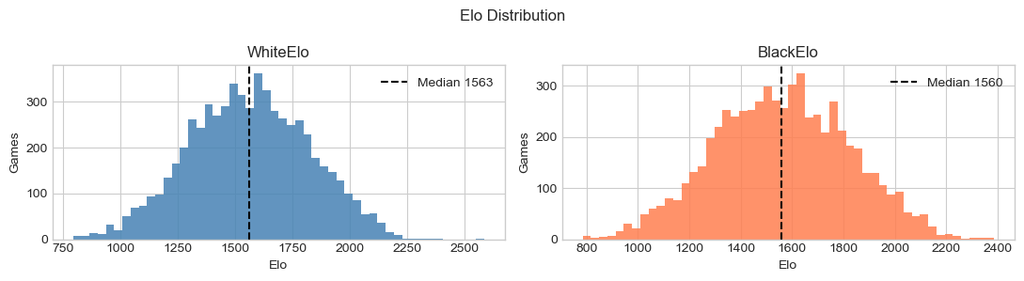

## 2 · Feature Engineering

We extract two groups of features that summarise a player's style without requiring real-time sequence processing at training time:

**Board features** (replayed via `chess_features_final.py`, ~30 columns): captures (density, first move, pawn vs piece), checks given, castling side/move, piece activity (consecutive same piece, queen before move 10), territory depth, and engine quality metrics (avg centipawn loss, blunders — NaN → 0 when evals absent).

**Clock features** (~10 columns): Average, std, max time spent per move; time pressure in the last 5 moves; opening pace in the first 5 moves. All normalised by the base time-control.

Both are cached to disk after the first run.

```
Extracting board features (a few minutes)...
Done  (35 cols  3s) — cached
Extracting clock features...
Done  (10 cols  1s) — cached
```

```
Static features: 45
['acpl_black', 'acpl_white', 'b_avg_time_norm', 'b_max_time_norm', 'b_opening_pace', 'b_std_time_norm', 'b_time_pressure', 'black_territory_depth', 'blunder_count_black', 'blunder_count_white', 'blunder_density_black', 'blunder_density_white', 'capture_density', 'castle_move_black', 'castle_move_whi…
```

## 3 · Preprocessing

### Soft Elo targets

Rather than predicting a single number, we predict a **probability distribution** over 40 Elo bins. The target for a player with true rating *e* is a Gaussian with σ = 200 centred on *e*, normalised to sum to 1.

Training with **KL divergence** against this soft target naturally captures rating uncertainty — the model learns that 1400 and 1600 are close, not unrelated.

### Weighted sampling

Very low and very high Elo games are rare. **Inverse-frequency weighted sampling** oversamples these games during training so the model generalises across all skill levels.

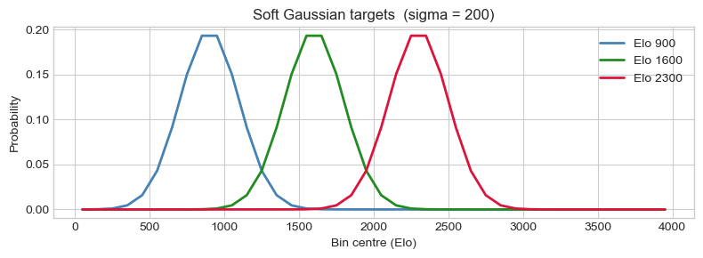

```
Train 4,975  val 622  test 622
Scaling applied (StandardScaler fit on train only)
```

```
Dropped 125 games shorter than 12 plies
Vocabulary: 3,270 distinct moves
```

```
Building datasets...
Built in 1s
Train batches per epoch: 39
```

```
============================================================
DATASET OVERVIEW
============================================================
  Train: 4,872  Val: 613  Test: 609
  Static feature dim : 45
  Sequence included  : True

============================================================
STATIC FEATURES  (sample game #0, before model)
============================================================
  tc_base                                  0.0000  ← NaN→0
  tc_inc                                  -0.1272
  total_ply_count                          1.4491
  material_balance_end                     1.2336
  result_encoded                           0.9784
  checks_given_white                      -0.2729
  checks_given_black                      -0.2140
  check_density_white                     -0.5788
  check_density_black                     -0.5031
  first_capture_move_white                 0.4486
  first_capture_move_black                 0.6416
  pawn_captures_total                      1.0613
  piece_captures_total                     0.9791
  capture_density                         -0.6029
  castle_move_white                       -1.2652
  castle_move_black                        1.0573
  consec_same_piece_white                  1.6233
  consec_same_piece_black                  0.9869
  queen_moves_before_10                   -0.9071
  white_territory_depth                    0.8271
  black_territory_depth                    0.8750
  promotions                               1.5451
  en_passant_captures                     -0.1612
  legal_moves_white_move5                 -0.6888
  legal_moves_black_move5                 -0.0198
  acpl_white                              -0.2999
  inaccuracy_count_white                  -0.2815
  mistake_count_white                     -0.2765
  blunder_count_white                     -0.2480
  blunder_density_white                   -0.2672
  acpl_black                              -0.2923
  inaccuracy_count_black                  -0.2793
  mistake_count_black                     -0.2744
  blunder_count_black                     -0.2480
  blunder_density_black                   -0.2620
  w_avg_time_norm                         -0.2116
  w_std_time_norm                          0.5253
  w_max_time_norm                          1.4157
  w_time_pressure                         -0.6447
  w_opening_pace                          -0.1334
  b_avg_time_norm                          0.0311
  b_std_time_norm                          0.0644
  b_max_time_norm                          0.6582
  b_time_pressure                         -0.5778
  b_opening_pace                           0.5244

============================================================
ELO DISTRIBUTION TARGETS  (sample game #0)
============================================================
  White actual Elo : 1158   Black actual Elo : 1253
  White dist peak  : 1150   Black dist peak  : 1250
  White dist sum   : 1.0000  (should be 1.0)
```

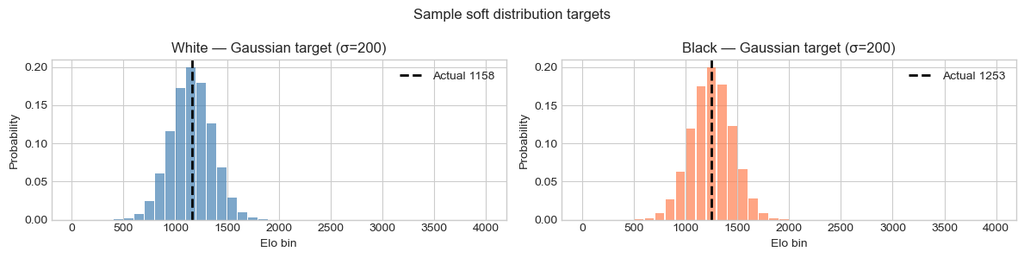

```
============================================================
MOVE SEQUENCE  (sample game #0)
============================================================
  Sequence length : 112 moves (capped at 120)

  Ply   Token ID   Move         Norm clock   Side
  ------------------------------------------------
  1     234        b3           2.000        White
  2     24         d5           2.000        Black
  3     235        Bb2          2.000        White
  4     218        e6           2.000        Black
  5     122        d3           2.000        White
  6     451        Nh6          2.000        Black
  7     319        f3           2.000        White
  8     212        Rg8          2.000        Black
  9     725        Be5          2.000        White
  10    236        Bd6          2.000        Black
  11    509        Bc3          2.000        White
  12    189        f6           2.000        Black
  13    235        Bb2          2.000        White
  14    725        Be5          2.000        Black
  15    226        Bxe5         2.000        White
  16    227        fxe5         2.000        Black
  17    2          e4           2.000        White
  18    305        dxe4         2.000        Black
  19    305        dxe4         2.000        White
  20    941        Qxd1+        2.000        Black
  ... (92 more moves)
```

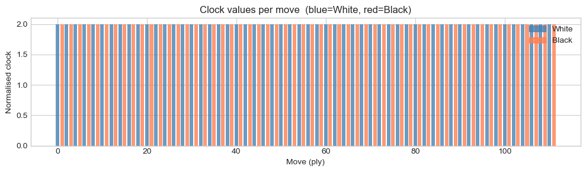

```
============================================================
ONE BATCH FROM train_loader
============================================================
  Keys in batch       : ['static', 'w_dist', 'b_dist', 'elos', 'moves', 'clocks', 'mask']
  static shape        : torch.Size([128, 45])   (batch_size × n_static_features)
  w_dist shape        : torch.Size([128, 40])   (batch_size × 40 bins)
  elos shape          : torch.Size([128, 2])     (batch_size × 2)
  moves shape         : torch.Size([128, 120])   (batch_size × padded_seq_len)
  clocks shape        : torch.Size([128, 120])
  mask shape          : torch.Size([128, 120])
  real tokens         : 8,097   padding tokens : 7,263
  avg sequence length : 63.3 moves in this batch

  Static feature stats across this batch:
  Feature                                  mean       std       min       max
  ------------------------------------------------------------------------
  tc_base                                 0.000     0.000     0.000     0.000
  tc_inc                                 -0.057     0.270    -0.127     1.659
  total_ply_count                         0.003     0.863    -1.560     2.743
  material_balance_end                   -0.132     1.060    -3.050     3.601
  result_encoded                          0.066     1.006    -1.071     0.978
  checks_given_white                     -0.016     0.945    -0.820     4.924
  checks_given_black                     -0.082     0.839    -0.769     3.395
  check_density_white                    -0.028     0.887    -0.983     3.700
  check_density_black                    -0.048     0.921    -0.923     2.435
  first_capture_move_white                0.003     0.931    -2.002     3.819
  ... (35 more features)
```

## 4 · Model Architectures

### Development history

**v1–v2 — BiLSTM baseline (MAE ≈ 200)**  
Initial model: two-layer BiLSTM over move sequences plus hand-crafted static features (captures, checks, castling, clock usage). Early experiments used a strict time-control filter (10 min only) that left just ~23 k games — too few to generalise. Relaxing to ≥ 3 min and scaling to 200 k → 1 M games brought MAE to ~200 Elo.

**v3 — Soft targets + KL divergence (MAE ≈ 185)**  
Switching from Huber regression to KL divergence over Gaussian soft targets improved calibration and reduced MAE by ~15 Elo. Inspired by Ouzounis et al. (2022).

**v4 — Clock features + 1 M games (MAE ≈ 165)**  
Adding per-move clock statistics (time pressure, opening pace) and training on 1 M games closed the gap further. A sequence autoencoder (BiLSTM → 32-d bottleneck) was also tested to pre-compute sequence embeddings for faster CPU training.

**This notebook — Four architectures compared**  
All models use the same data, features, loss, and training loop for a fair comparison.

### Model 1 · BiLSTM with soft attention

A two-layer **bidirectional LSTM** reads the move sequence and produces a hidden state at each position. **Soft attention** learns to weight these states, allowing the model to focus on the most informative moves.

- *Strength*: captures long-range move dependencies and is sensitive to move order.
- *Weakness*: sequential computation cannot be parallelised; can lose signal from early moves in long games.

### Model 2 · Residual MLP (features only)

A deep **residual MLP** over the static feature vector — no move sequences.

Each residual block applies `LayerNorm → Linear → GELU → Dropout → Linear` and adds the result back via a skip connection. Pre-norm residual connections train stably at depth and avoid gradient vanishing.

- *Strength*: fastest to train, no sequence overhead, very interpretable.
- *Weakness*: cannot see *which moves* were played, only aggregate statistics.

### Model 3 · Multi-scale 1D CNN

**Three parallel Conv1d branches** with kernel sizes 3, 5, and 7 capture move patterns at different scales: short tactics (k=3), medium plans (k=5), and longer strategic ideas (k=7). After convolution, **global max-pooling** picks the strongest filter activation across the whole game.

### Model 4 · Transformer Encoder

**Multi-head self-attention** lets every move attend to every other move in O(1), unlike LSTM which passes information through a chain of sequential states.

We use **sinusoidal positional encodings** (fixed, not learned) and **pre-norm layers** which train more stably at depth. After encoding, we **mean-pool** over non-padding positions.

- *Strength*: direct connections between any pair of moves; highly parallelisable on GPU.
- *Weakness*: quadratic memory in sequence length

## 5 · Training

All models share the same training loop:

- **Loss**: KL divergence between log-softmax predictions and the Gaussian soft targets
- **Optimiser**: AdamW with cosine annealing (LR decays to 5% of initial)
- **Gradient clipping** at norm 1.0
- **Early stopping**: restores best weights if validation MAE does not improve for `PATIENCE` consecutive epochs

## 5a · Hyperparameter Optimisation (optional)

When `HPO_*` is enabled for a model, [Optuna](https://optuna.org/) runs a quick search before the full training. Each trial trains on a small subset (`HPO_GAMES`) for a few epochs (`HPO_EPOCHS`) and evaluates on the validation set.

The best parameters are cached to `checkpoints/hpo_*.pkl` — re-running the cell is instant if the cache exists (delete the file to force a fresh search).

If HPO is disabled, the default values from the config cell are used.

**Searched parameters:**

- *BiLSTM*: hidden dim, dropout
- *Residual MLP*: hidden dim, number of residual blocks, dropout
- *CNN*: filters per branch, embedding dim, dropout
- *Transformer*: d_model, attention heads, encoder layers, feedforward dim, dropout

```
HPO disabled — using default hyperparameters from config

Final params:
  BiLSTM      : {'hidden': 128, 'dropout': 0.3}
  Residual MLP: {'hidden': 256, 'n_blocks': 4, 'dropout': 0.3}
  CNN         : {'n_filters': 64, 'embed_dim': 64, 'dropout': 0.3}
  Transformer : {'d_model': 128, 'n_heads': 4, 'n_layers': 2, 'ff_dim': 256, 'dropout': 0.3}
```

```
Training BiLSTM
----------------------------------------
   1/10  loss=2.5958  val_mae=235.1  22.3s
   2/10  loss=1.7590  val_mae=198.0  21.8s
   3/10  loss=1.3656  val_mae=204.4  20.5s
   4/10  loss=1.1886  val_mae=200.7  19.2s
   5/10  loss=1.0860  val_mae=195.8  21.2s
   6/10  loss=1.0093  val_mae=190.9  24.5s
   7/10  loss=0.9556  val_mae=198.1  24.4s
   8/10  loss=0.9436  val_mae=191.1  24.9s
   9/10  loss=0.9069  val_mae=193.1  23.8s
  Early stop at epoch 9
  Total training time: 3m 22s
  Test MAE: 193.7

Training Residual MLP
----------------------------------------
   1/10  loss=1.6634  val_mae=211.3  1.1s
   2/10  loss=1.0401  val_mae=211.0  1.2s
   3/10  loss=0.9391  val_mae=214.0  1.1s
   4/10  loss=0.8872  val_mae=203.2  1.1s
   5/10  loss=0.8745  val_mae=204.4  1.1s
   6/10  loss=0.8141  val_mae=203.7  1.2s
   7/10  loss=0.8041  val_mae=206.5  1.1s
  Early stop at epoch 7
  Total training time: 0m 7s
  Test MAE: 205.0

Training CNN
----------------------------------------
   1/10  loss=2.4135  val_mae=216.4  3.1s
   2/10  loss=1.6000  val_mae=197.3  3.1s
   3/10  loss=1.0825  val_mae=197.2  3.2s
   4/10  loss=0.7550  val_mae=195.9  2.9s
   5/10  loss=0.6268  val_mae=184.3  2.9s
   6/10  loss=0.5506  val_mae=188.3  2.8s
   7/10  loss=0.4918  val_mae=186.1  2.9s
   8/10  loss=0.4649  val_mae=186.2  2.8s
  Early stop at epoch 8
  Total training time: 0m 23s
  Test MAE: 185.2

Training Transformer
----------------------------------------
   1/10  loss=2.3145  val_mae=215.8  12.8s
   2/10  loss=1.6592  val_mae=203.9  12.8s
   3/10  loss=1.2254  val_mae=196.4  12.7s
   4/10  loss=1.0013  val_mae=200.4  13.0s
   5/10  loss=0.9175  val_mae=191.7  14.3s
   6/10  loss=0.8459  val_mae=187.9  13.4s
   7/10  loss=0.8021  val_mae=192.5  13.5s
   8/10  loss=0.7916  val_mae=191.7  12.5s
   9/10  loss=0.7808  val_mae=187.6  13.4s
  Early stop at epoch 9
  Total training time: 1m 58s
  Test MAE: 183.3
```

## 6 · Results & Comparison

```
Games with MAE <= 78 Elo: 122

Sharp prediction — error: 33 Elo   entropy: 2.406
Flat  prediction — error: 57 Elo   entropy: 2.746
```

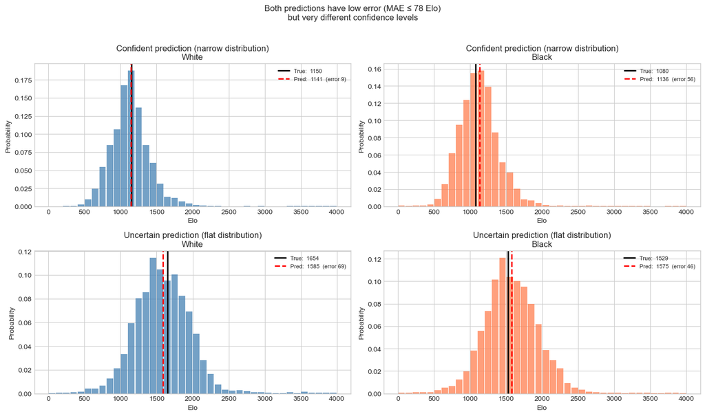

```
             White MAE Black MAE Combined MAE Within 100 Within 200 Within 300
Model
BiLSTM           194.7     192.7        193.7      17.4%      45.0%      71.6%
Residual MLP     205.9     204.0        205.0      16.6%      40.7%      67.2%
CNN              190.2     180.3        185.2      19.5%      47.0%      70.0%
Transformer      184.9     181.6        183.3      18.9%      48.1%      74.9%
```

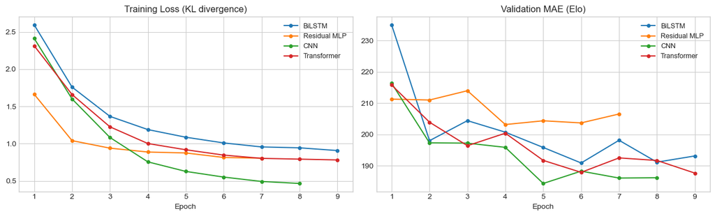

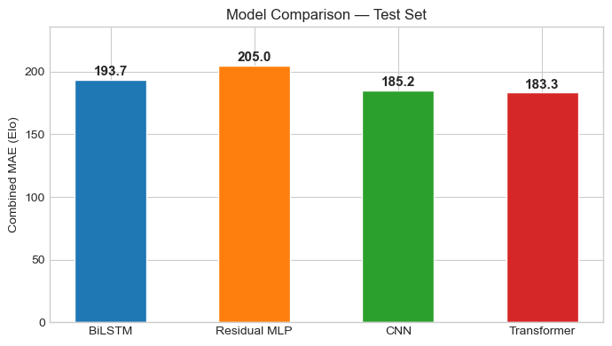

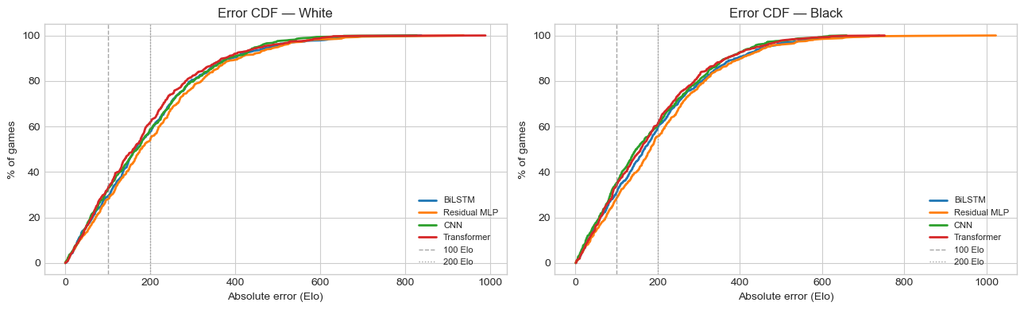

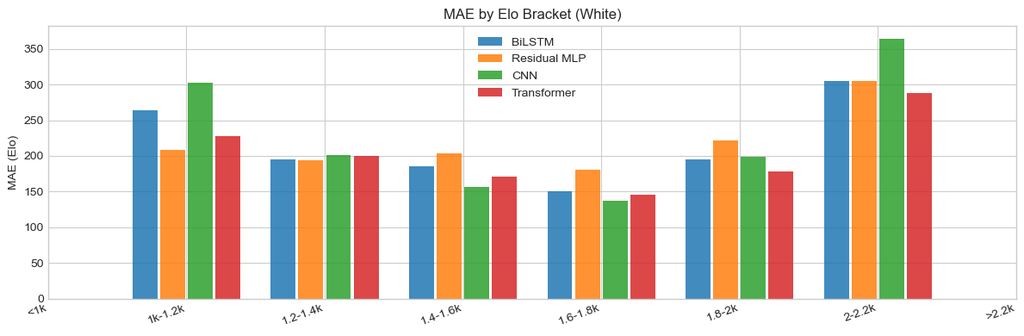

```
=================================================================
FEATURE IMPORTANCE — all models
=================================================================

  Computing for BiLSTM...
    Base MAE: 193.7

  Computing for Residual MLP...
    Base MAE: 205.0

  Computing for CNN...
    Base MAE: 185.2

  Computing for Transformer...
    Base MAE: 183.3

=================================================================
DELTA MAE  (positive = removing this hurts the model)
=================================================================
  Feature / Branch                         BiLSTM   Residual MLP            CNN    Transformer
  --------------------------------------------------------------------------------------------
  static: game_structure                      3.2            9.2            0.5            1.1
  static: checks                             -0.5           -4.0            2.6            1.6
  static: captures                            3.2           10.5            0.6            3.2
  static: castling                           -0.1           -1.3            0.1            0.0
  static: style                               3.9           18.6            6.3            7.7
  static: engine_quality                      1.9            2.2            0.4            2.9
  static: clock                               4.1            8.1            4.6            4.9
  static: tc_meta                             0.5            1.6            0.3            0.8
  [remove sequence]                          58.2              —           26.7          139.1
  [remove static]                            95.9              —           27.4           17.7
  seq phase: Early (1-15)                    -0.7              —            7.9           18.5
  seq phase: Mid (1-30)                      -0.4              —           -0.5            2.8
  --------------------------------------------------------------------------------------------
  Base MAE                                  193.7          205.0          185.2          183.3
```

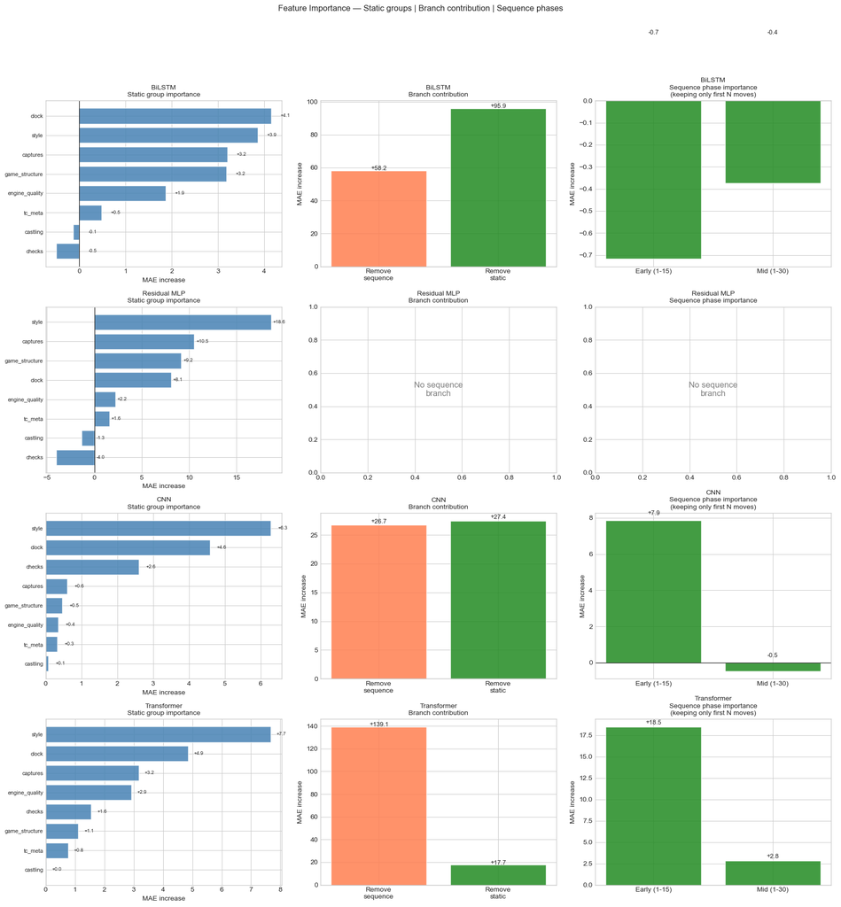

```
SUMMARY
-------------------------------------------------------

  BiLSTM  (base MAE = 193.7)
    Most important static group : clock  (Δ=+4.1)
    Removing sequence adds      : +58.2 Elo
    Removing static adds        : +95.9 Elo
    Dominant branch             : static

  Residual MLP  (base MAE = 205.0)
    Most important static group : style  (Δ=+18.6)

  CNN  (base MAE = 185.2)
    Most important static group : style  (Δ=+6.3)
    Removing sequence adds      : +26.7 Elo
    Removing static adds        : +27.4 Elo
    Dominant branch             : static

  Transformer  (base MAE = 183.3)
    Most important static group : style  (Δ=+7.7)
    Removing sequence adds      : +139.1 Elo
    Removing static adds        : +17.7 Elo
    Dominant branch             : sequence
```

```
===========================================================================
INDIVIDUAL STATIC FEATURE IMPORTANCE — top 15 per model
===========================================================================

  Computing for BiLSTM...

  Computing for Residual MLP...

  Computing for CNN...

  Computing for Transformer...

  BiLSTM  (base MAE = 193.7)
  Rank   Feature                                   Delta MAE
  ----------------------------------------------------------
  1      total_ply_count                               +2.39  ████
  2      b_avg_time_norm                               +2.37  ████
  3      w_time_pressure                               +1.40  ██
  4      capture_density                               +1.18  ██
  5      material_balance_end                          +0.91  █
  6      first_capture_move_white                      +0.66  █
  7      white_territory_depth                         +0.60  █
  8      consec_same_piece_white                       +0.54  █
  9      en_passant_captures                           +0.54  █
  10     consec_same_piece_black                       +0.49
  11     tc_inc                                        +0.47
  12     blunder_density_black                         +0.46
  13     acpl_white                                    +0.42
  14     castle_move_black                             +0.38
  15     b_max_time_norm                               +0.37

  Residual MLP  (base MAE = 205.0)
  Rank   Feature                                   Delta MAE
  ----------------------------------------------------------
  1      total_ply_count                              +10.51  █████████████████████
  2      piece_captures_total                          +6.37  ████████████
  3      consec_same_piece_white                       +5.24  ██████████
  4      capture_density                               +4.32  ████████
  5      b_std_time_norm                               +4.26  ████████
  6      w_std_time_norm                               +4.02  ████████
```

[output cut: 32 more lines]

```
  1      capture_density                               +2.27  ████
  2      blunder_density_black                         +1.71  ███
  3      check_density_white                           +1.60  ███
  4      acpl_white                                    +1.53  ███
  5      total_ply_count                               +1.49  ██
  6      first_capture_move_white                      +1.09  ██
  7      w_max_time_norm                               +1.08  ██
  8      b_max_time_norm                               +1.03  ██
  9      w_std_time_norm                               +0.96  █
  10     w_avg_time_norm                               +0.87  █
  11     consec_same_piece_white                       +0.78  █
  12     tc_inc                                        +0.77  █
  13     b_std_time_norm                               +0.74  █
  14     w_time_pressure                               +0.70  █
  15     black_territory_depth                         +0.63  █
```

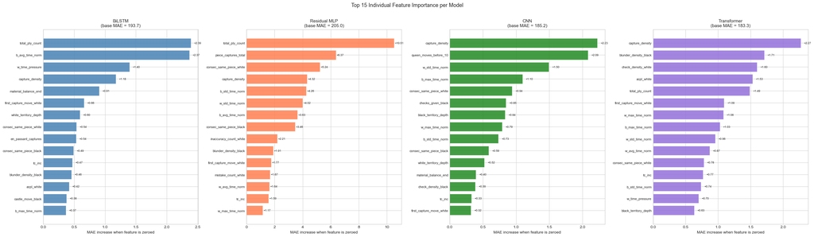

## 7 · Ensemble

When multiple models are trained, we average their **predicted distributions** (not just the point estimates). Because each model's errors are partially independent, ensemble averaging typically improves both accuracy and calibration.

```
Ensemble combined MAE: 176.6  (White 178.5, Black 174.8)
```

```
==================================================
             Combined MAE Within 100 Within 200 Within 300
Model
BiLSTM              193.7      17.4%      45.0%      71.6%
Residual MLP        205.0      16.6%      40.7%      67.2%
CNN                 185.2      19.5%      47.0%      70.0%
Transformer         183.3      18.9%      48.1%      74.9%
Ensemble            176.6      18.9%      50.1%      77.3%
==================================================
Best single model: Transformer  (MAE = 183.3)
```

## 8 · Single Game Demo

Paste any PGN string below and run the cell to predict both players' Elo ratings using every trained model.

```
Model                White Elo   Black Elo
--------------------------------------------
  BiLSTM                  1811        1795
  Residual MLP            1598        1581
  CNN                     1705        1684
  Transformer             1718        1706
```